# Homework #6

Dustin Leatherman

5/17/2020

# 9

> Consider a distribution with the density function as
> $$\frac{1}{B(\alpha, \beta)}x^{\alpha - 1}(1 - x)^{\beta - 1}, \ \ 0 \leq x \leq 1$$
> Derive a rejection-acceptance method for generating random variables with above pdf with $\alpha = 2, \beta = 2$ from $U[0,1]$ random variables. Generate 1000 such numbers.

With $\alpha = 2, \ \beta = 2$.

$$\frac{1}{B(2, 2)}x(1 - x)$$
$\frac{1}{B(2,2)} = \frac{\Gamma (\alpha + \beta)}{\Gamma(\alpha) \Gamma (\beta)} = \frac{(4 - 1)!}{(2 - 1)! \cdot (2 - 1)!} = 6$

Thus,

$$6x(1 - x)$$

$Q = \frac{f_X(y)}{f_Y(y)} = \frac{6x(1 - x)}{1}$

$\frac{\partial Q}{\partial x} = 6 - 12x = 0 \to x = \frac{1}{2}$

Number simulations required to run

$N = 1.1 \cdot E(N) = \frac{1000}{c} \cdot1.1 = \frac{3}{2} \cdot 1000 \cdot 1.1 = 1650$

Accept-Rejection Decision

$$W_i \leq \frac{2}{3} \cdot 6x(1 - x) = 4x(1 - x)$$

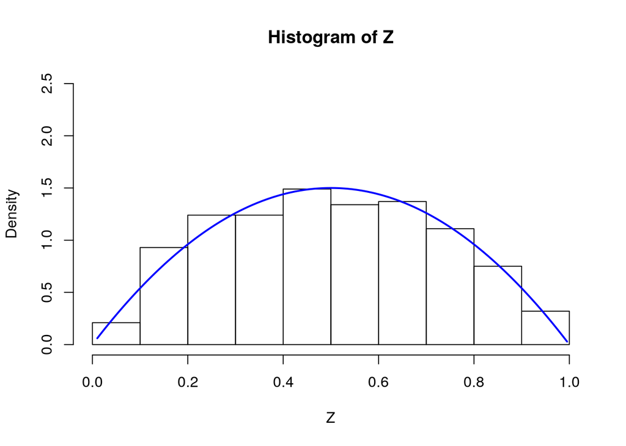

```r
set.seed(23423523)
n<-10^3
efficiency <- (2/3)
N<-ceiling(n/efficiency*1.1)
X <- runif(N)
W <- runif(N)

Z <- X[which(efficiency * 6 * X * (1 - X) >= W)]
Z <- Z[1:n]

hist(Z, freq=F, ylim=c(0,2.5))

xfit <- seq(min(Z), max(Z),length=1000)
lines(xfit, 6 * xfit * (1 - xfit),col='blue',lwd=2)
```

# 10

> Consider the problem of pricing lookback options for a stock modeled by a geometric Brownian motion with an initial price of $100, a volatility of 40%, and zero interest rate. Let the expiry time be 12 weeks in the future (consider 52 weeks a year), and let the monitoring frequency be weekly.

$S(0) = 100$

$\sigma = 0.4$

$r = 0$

$T = 12/52$

$d = 12$

## a

> Find the fair price of both the put and call options

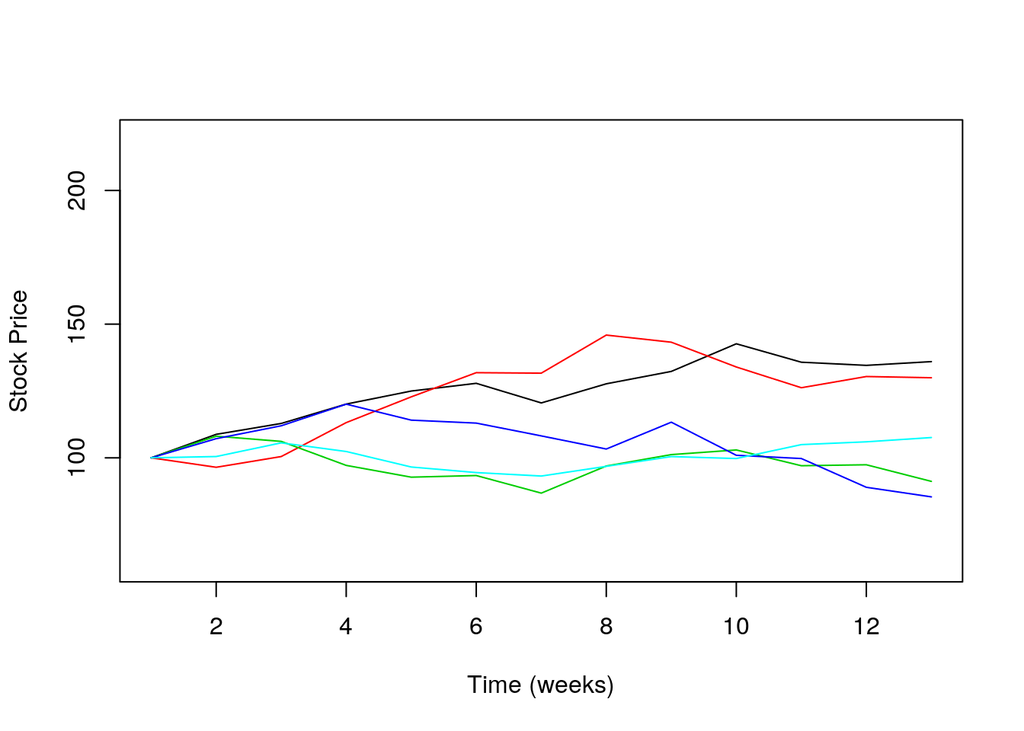

```r
s0 <- 100
sigma <- 0.4
r <- 0
t <- (12/52)
d <- 12
n <- 5
delta <- t/d
grid <- seq(delta, t, length.out = d)

#create a matrix to store asset prices
S <- matrix(rep(0, n * (d + 1)), nrow = n)

#generate nxd pseudo-random normal numbers
x <- matrix(rnorm(n * d), nrow = n)

#generate n sample paths of Brownian Motion
BM <- sqrt(delta) * t(apply(x, 1, cumsum))

S <- cbind(rep(s0, n), s0 * exp(sweep(sigma * BM, MARGIN = 2, (r - sigma^2 / 2) * grid, '+')))

plot(1:(d+1),S[1,],type='l',ylim=c(60,220),col=1,ylab='Stock Price',xlab='Time (weeks)')
for (i in 2:n){
    points(1:(d+1),S[i,],type='l',col=i)
}
```

```r
fair.call <- mean(rep(s0, n) - apply(S, 1, min))

fair.put <- mean(apply(S, 1, max) - rep(s0, n))
```

The Fair Price for Call option under these terms is $7.63

The Fair Price for Put option under these terms is $24.86

## b

> Does the put or the call have a higher price? What is a possible intuitive explanation?